# Python - ML - Supervised Learning

### Topic 1: Supervised Learning Overview

*Supervised Learning* algorithms are trained using *labeled* examples, such as an input where the desired output is known.

Machine Learning Process -

[figure not shown]

Data is often split into 3 sets -

1. Training data - Used to train model parameters
2. Validation data - Used to determine what model hyperparameters to adjust
3. Test data - Used to get some final performance metrics

This means after we see the results on the *final test set* we do not get to go back an adjust any model parameters!

This final measure is what we label the true performance of the model are.

### Topic 2: Evaluating Performance - Classification Error Metrics

We just learned that after our machine learning process is complete, we will use performance metrics to evaluate how our model did.

The key classification metrics we need to understand are:

- **Accuracy**
- **Recall**
- **Precision**
- **F1-Score**
1. Understand the reasoning behind these metrics and how they will actually work in the real world.

   Typically in any classification task your model can only achieve two results:
   - Either your model was correct in its prediction.
   - Or you model was incorrect in its prediction.
2. Fortunately incorrect vs correct expands to situations where you have multiple classes.
3. For the purposes of explaining the metrics, let's imagine a **binary classification** situation, where we only have two available classes.

### Model Evaluation

**Method 1:**

In our example, we will attempt to predict if an image is a dog or a cat.

Since this is supervised learning, we will first **fit/train** the model on **training data**, then **test** the model on **testing data**.

Once we have the model's predictions from the **X_test** data, we compare it to the **true y values** (the correct labels). We repeat this process for all the images in our X test data. At the end we will have a count of correct matches and a count of incorret matches. The key realization we need to make, is that **in teh real world, not all incorrect or correct matches hold equal value!** Also in the real world, a single metric won't tell the complete story. To understand all of this, let's bring back the 4 metrics we mentioned and see how they are calculated. We could organize our predicted values compared to the real values in a **confusion matrix**.

**Accuracy**: Accuracy in classification problems is the **number of correct predictions** made by the model divided by the **total number of predictions**. For example, if the X_test set was 100 images and our model **correctly** predicted 80 images, then we have 80/100. That is, 0.8 or 80% **accuracy**. Accuracy is useful *when target classes are well balanced*. In our example, we would have roughly the same amount of cat images as we have dog images. Accruacy is **not** a good choice with **unbalanced** classes! Imagine we had 99 images of dogs and 1 image of a cat. If our model was simply a line that always predicted **dog** we would get 99% accuracy! In this situation, we will to understand **recall** and **precision**.

**Recall**: Ability of a model to find all the revelant cases within a dataset. The precise definittion of **recall** is the number of true positive **divided by** the number of true positives plus the number of false negatives.

**Precision**: Ability of a classficition model to identify only the relevant data points. Precision is defined as the number of true positive divided by the number of true positive plus the number of false positive.

**F1 score**: In cases where we want to find an optimal blend of precision and recall we can combine the two metrics using what is called F1 Score. The F1 score is the harmonic mean of precision and recall taking both metrics into account in the following equation. We use the harmonic mean instead of a simple average because it punishes extreme values. A classifier with a precision of 1.0 abd a recall of 0.0 has a simple average 0.5 but an F1 score of 0.

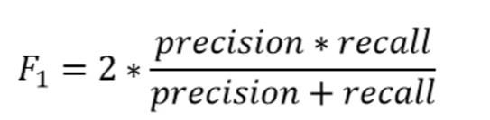

**Method 2:**

We can also view all correctly classified versus incorrectly classified images in the form of a confusion matrix. The main point to remember with the confusion matrix and the various calculated metrics is that they are all fundamentally ways of comparing the predicted values versus the true values. What constitues "good" metrics, will really depend on the specific situation!

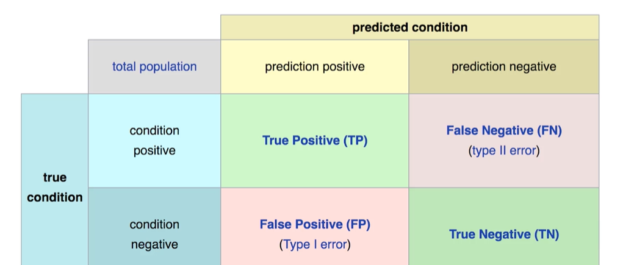

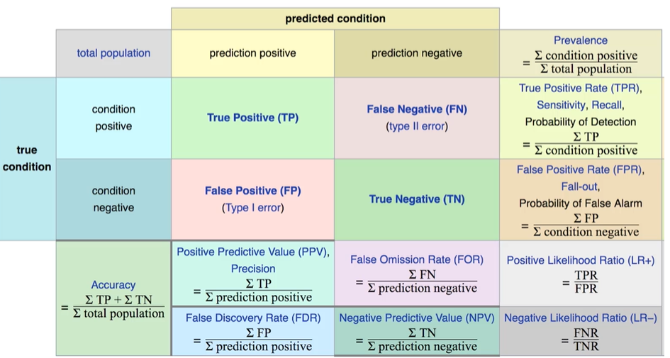

Often we have a precision/recall trade off, we need to decide if the model will should focus on fixing False Positive vs False Negatives. In disease diagnoses, it is probably better to go in the direction of False positives, so we make sure we correctly classify as many cases of disease as possible.

### Topic 3: Evaluating Performance - Regression Error Metrics

Regression is a task when a model attempts to predict continuous values (unlike categorical values, which is classification).

Let's discuss some of the most common evaluation metrics for regression:

- **Mean Absolute Error**
- **Mean Squared Error**
- **Root Mean Square Error**

**Mean Absolute Error**: This is the mean of the absolute value of error. **However, MAE won't punish large errors.**

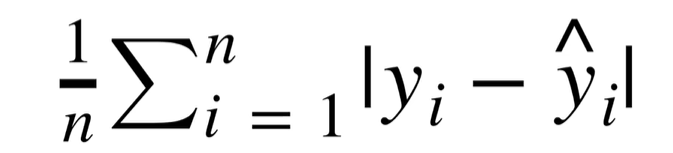

**Mean Squared Error**: This is the mean of the squared error. Larger errors are noted more than with MAE, making MSE more popular. However, it does not have the same unit as Y.

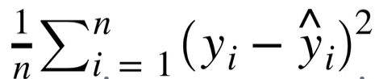

**Root Mean Squared Error**: This is the root of the mean of the squared root. Most popular. It has the same units as y.

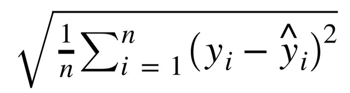